# Proje Rapor : Dilek Durmuş 210401097

# Q1 : Problem tanımı

Şirketimiz DAppGenius , problemimiz uygulamalarımızın beklenen indirme seviyelerinin altında kalması.

# Q2 : Proje Amacı

Datasette yer alan Category, Rating ve Installs sütunlarındaki veriler incelenerek, Rating değeri 4.0 ve üzeri olan ve Installs değeri 1M ve üzeri olan uygulamalar belirlenecek.Bu uygulamalar kategorilere göre guruplara ayrılacak böylece pazar payları ve oranları incelenecek. Elde edilen bilgiler doğrultusunda, pazar hakkında bilgi sahibi olup uygulamaları daha bilinçli bir şekilde seçeceğiz.

# Q3 : Veri seti keşifsel analizi

Bu veri seti www.kaggle.com sitesinden elde edilmiştir (“https://www.kaggle.com/datasets/lava18/google-play-store-apps”).Bu veriler google play store’dan toplanmış verilerdir.

- Toplam uygulama sayısı : 10841
- Sütun sayısı : 13
- Veri setinin ön görsellemesi aşağıda verilmiştir.

| App | Category | Rating | Reviews | Size | Installs | Type | Price | Content.Rating | Genres | Last.Updated | Current.Ver | Android.Ver |
| --- | --- | --- | --- | --- | --- | --- | --- | --- | --- | --- | --- | --- |
| Photo Editor & Candy Camera & Grid & ScrapBook | ART_AND_DESIGN | 4.1 | 159 | 19M | 10,000+ | Free | 0 | Everyone | Art & Design | January 7, 2018 | 1.0.0 | 4.0.3 and up |
| Coloring book moana | ART_AND_DESIGN | 3.9 | 967 | 14M | 500,000+ | Free | 0 | Everyone | Art & Design;Pretend Play | January 15, 2018 | 2.0.0 | 4.0.3 and up |
| U Launcher Lite – FREE Live Cool Themes, Hide Apps | ART_AND_DESIGN | 4.7 | 87510 | 8.7M | 5,000,000+ | Free | 0 | Everyone | Art & Design | August 1, 2018 | 1.2.4 | 4.0.3 and up |
| Sketch - Draw & Paint | ART_AND_DESIGN | 4.5 | 215644 | 25M | 50,000,000+ | Free | 0 | Teen | Art & Design | June 8, 2018 | Varies with device | 4.2 and up |
| Pixel Draw - Number Art Coloring Book | ART_AND_DESIGN | 4.3 | 967 | 2.8M | 100,000+ | Free | 0 | Everyone | Art & Design;Creativity | June 20, 2018 | 1.1 | 4.4 and up |
| Paper flowers instructions | ART_AND_DESIGN | 4.4 | 167 | 5.6M | 50,000+ | Free | 0 | Everyone | Art & Design | March 26, 2017 | 1.0 | 2.3 and up |
| Smoke Effect Photo Maker - Smoke Editor | ART_AND_DESIGN | 3.8 | 178 | 19M | 50,000+ | Free | 0 | Everyone | Art & Design | April 26, 2018 | 1.1 | 4.0.3 and up |
| Infinite Painter | ART_AND_DESIGN | 4.1 | 36815 | 29M | 1,000,000+ | Free | 0 | Everyone | Art & Design | June 14, 2018 | 6.1.61.1 | 4.2 and up |
| Garden Coloring Book | ART_AND_DESIGN | 4.4 | 13791 | 33M | 1,000,000+ | Free | 0 | Everyone | Art & Design | September 20, 2017 | 2.9.2 | 3.0 and up |
| Kids Paint Free - Drawing Fun | ART_AND_DESIGN | 4.7 | 121 | 3.1M | 10,000+ | Free | 0 | Everyone | Art & Design;Creativity | July 3, 2018 | 2.8 | 4.0.3 and up |

[output cut: 9990 more lines]

Veri setini incelediğimizde problemimizi çözmemize yardımcı olacak sütunlar şunlardır; **Category, Installs, Rating**. Kalan sütunları sileceğim.

- **Category** sütunu bize **char** tipinde gelmektedir. Bu tip bizim için uygundur. Bir değişiklik yapmamıza gerek yoktur. Bu sütunda herhangi bir NULL değeri bulunmamaktadır.
- **Installs** sütunu **char** tipindedir. Aynı zamanda NA ve NaN değerlerinin temizlenmesi ve değerlerin “,” ve “+” ifadelerinden kurtulması daha sonra numeric tipe çevrilmesi gerekmektedir.
- **Rating** sütunu ise **double** formatındadır. Fakat NA ve NaN değerlerinden temizlenmesi ve 1-5 paun dışındaki verilerin silinmesi gerekmektdir.

# Q4 : Veri seti ön işlemesi

**Temizlenmiş Tablo**

|  | Category | Installs | Rating |
| --- | --- | --- | --- |
| 1 | ART_AND_DESIGN | 1e+04 | 4.1 |
| 2 | ART_AND_DESIGN | 5e+05 | 3.9 |
| 3 | ART_AND_DESIGN | 5e+06 | 4.7 |
| 4 | ART_AND_DESIGN | 5e+07 | 4.5 |
| 5 | ART_AND_DESIGN | 1e+05 | 4.3 |
| 6 | ART_AND_DESIGN | 5e+04 | 4.4 |
| 7 | ART_AND_DESIGN | 5e+04 | 3.8 |
| 8 | ART_AND_DESIGN | 1e+06 | 4.1 |
| 9 | ART_AND_DESIGN | 1e+06 | 4.4 |
| 10 | ART_AND_DESIGN | 1e+04 | 4.7 |

[output cut: 9356 more lines]

- 10.841 adet veri satırından temizlik sonucu 9.366 adet veri elde ettim.
- Install sütunu “+” ve “,” karakterlerinden kurtulmuş, NA ve NaN değerleri silinmiş ve *numeric* tipe çevrilmiştir.
- Rating sütunu 1 ve 5 arası değerler kalmış gerisi silinmiş olup NA ve NaN değerleri de atılmıştır.

# Q5 : Veri mühendisliği

Şimdi ise temizlenmiş kullanılabilir verimizin içinden isteğimize uygun olan değerleri filtreleyeceğim. Installs değeri en az **1 milyon** olan ve Rating değeri en az **4.0** olan uygulamalarımızı alacağım. Bu aşamaya kadar uygulamaların isimleri önemli değil sadece kategorilerini bilmemiz yeterli.

**Filtrelenmiş Tablo**

|  | Category | Installs | Rating |
| --- | --- | --- | --- |
| 3 | ART_AND_DESIGN | 5e+06 | 4.7 |
| 4 | ART_AND_DESIGN | 5e+07 | 4.5 |
| 13 | ART_AND_DESIGN | 1e+07 | 4.2 |
| 19 | ART_AND_DESIGN | 5e+06 | 4.3 |
| 20 | ART_AND_DESIGN | 1e+07 | 4.6 |
| 38 | ART_AND_DESIGN | 5e+06 | 4.1 |
| 43 | ART_AND_DESIGN | 1e+07 | 4.4 |
| 46 | ART_AND_DESIGN | 1e+07 | 4.7 |
| 68 | AUTO_AND_VEHICLES | 5e+06 | 4.3 |
| 70 | AUTO_AND_VEHICLES | 5e+06 | 4.2 |

[output cut: 2586 more lines]

Bu aşamada, her kategorinin toplam **install** sayısı belirlendi, ortalama **rating** değerleri hesaplandı ve her kategoride kaç uygulama olduğu ölçüldü. Bu veriler üzerinden her kategorinin ve kategorilere göre uygulama başına düşen pazar payı hesaplamaları yapıldı ve tabloya aktarıldı.

**Gruplandırılmış tablo**

| Category | Installs_Million | Rating | Count | Market_Share | Market_Share_per_App |
| --- | --- | --- | --- | --- | --- |
| ART_AND_DESIGN | 115 | 4.43 | 9 | 0.07 | 0.01 |
| AUTO_AND_VEHICLES | 35 | 4.38 | 5 | 0.02 | 0.00 |
| BEAUTY | 15 | 4.25 | 2 | 0.01 | 0.00 |
| BOOKS_AND_REFERENCE | 890 | 4.41 | 40 | 0.57 | 0.01 |
| BUSINESS | 875 | 4.31 | 47 | 0.56 | 0.01 |
| COMICS | 35 | 4.40 | 5 | 0.02 | 0.00 |
| COMMUNICATION | 32520 | 4.31 | 158 | 20.76 | 0.13 |
| DATING | 200 | 4.23 | 24 | 0.13 | 0.01 |
| EDUCATION | 805 | 4.48 | 55 | 0.51 | 0.01 |
| ENTERTAINMENT | 2515 | 4.31 | 57 | 1.61 | 0.03 |

[output cut: 23 more lines]

# Q6 : Veri analizi

Buraya kadar analizlerimi tamamladım ve gruplara göre pazar paylarını araştırdım ve aşağıdaki pasta grafiğini elde ettim.

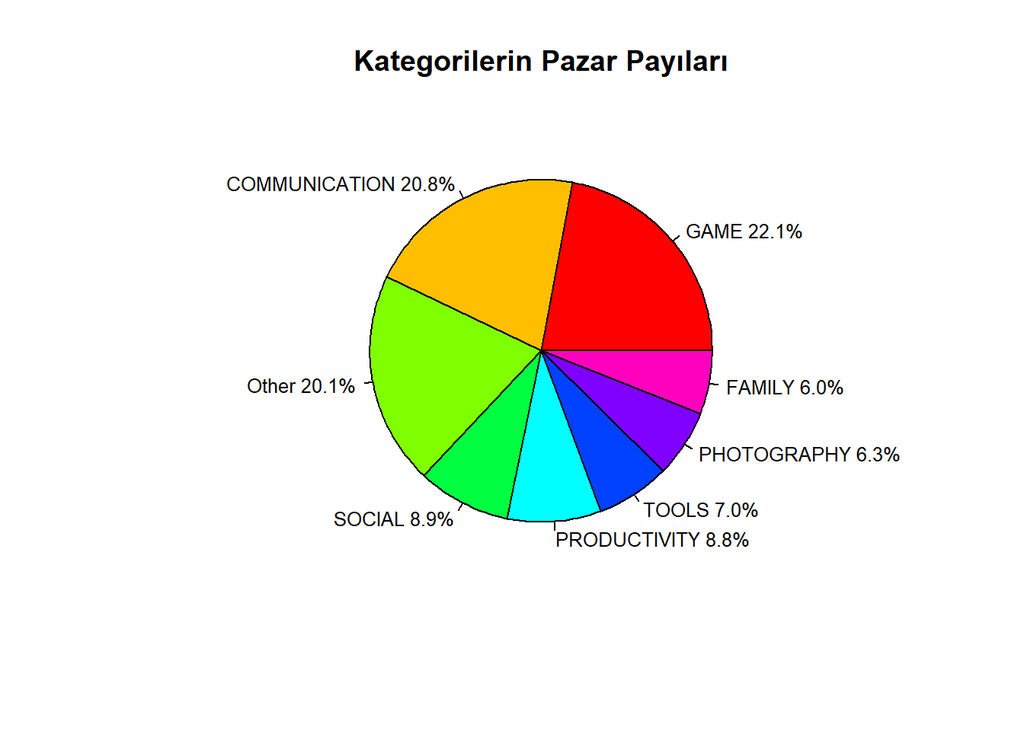

Aşağıdaki histogramda, her bir kategoride belirli bir sayıda uygulamanın bulunduğunu ve her uygulamanın kendi kategorisindeki pazar payını araştırdım. Bu pazar payı oranları, tüm pazarın genel oranına eşittir. Yani, her bir değer aşağıdaki X kategorisindeki bir uygulamanın ortalama pazar payını ifade etmektedir.

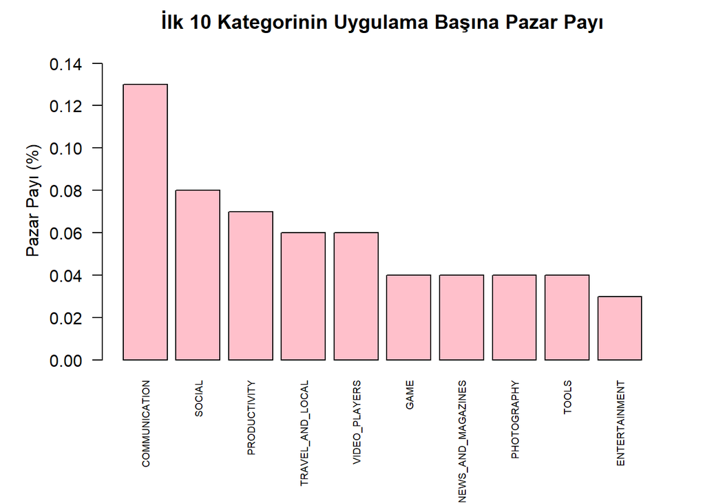

# Q7 : Sonuç değerlendirme, tavsiyeler

Projemizdeki temel hedef, popüler kategorilerdeki uygulamaları belirleyerek pazar stratejimizi bu yönde şekillendirmekti. Elde ettiğimiz sonuçlar istediğimiz doğrultuda, ancak veri setindeki bazı yanıltıcı durumlar göz önünde bulundurulmalıdır. Özellikle, ‘Installs’ sütunundaki verilerin dağılım aralıkları oldukça geniştir, 1.000.000’den 1.000.000.000’e kadar uzanmaktadır. Bu durum, kesin verilere ulaşmayı zorlaştırabilir ve skaladaki geniş aralıklar nedeniyle yanıltıcı sonuçlara yol açabilir. Ancak, projemde sayısal değerlerden ziyade oranlar üzerinden çalıştığım için bu olası yanılgıyı azalttım. Veri setimizdeki dağılım aralıklarını azaltarak veya doğrudan sayılar kullanarak daha sağlıklı sonuçlar elde edebiliriz.

Sonuç olarak, projemizden elde ettiğimiz verilere dayanarak, uygulama kategorilerinin pazar payı oranlarına odaklanarak en iyi performans gösteren kategorileri belirledik. Bu kategoriler sırasıyla şunlardır: Game (22.11), Communication (20.76), Social (8.87) ve Productivity (8.84). Ayrıca, her bir uygulama kategorisinin başına düşen pazar payı oranlarına bakarak en etkili kategorileri belirledik: Communication (0.13), Social (0.08), Productivity (0.07) ve Travel/Local (0.06).

Bu sonuçlara dayanarak, pazar payımızı genişletmek için daha iyi uygulamaları seçerek stratejimizi güçlendireceğiz.